# M/K in policy

Ernesto Carrella

11/11/2020

We have lots of demos now on the $\frac M K$ ratio. It matters to us because it is an integral component of the SPR formula. Unfortunately we have no idea what the “correct” $\frac M K$. Should we be worried?

We know that $\frac M K$ is important for **assessment** (i.e. what is the current SPR?). However what matters more is how guessing the wrong $\frac M K$ affects **policy**.  
If the real $\frac M K$ is 0.8 but when we compute SPR we assumed it was 1.2, our SPR will be off, sure, but over time will it matter or will it be the case that as long as we measure and act, over time we will control the fishery anyway?

If we think in terms of policy rather than assessment, $\frac M K$ is better understood as a “risk buffer” parameter. The lower we guess $\frac M K$ to be, the more strict our controls will be (implement deeper effort reductions, faster and for longer). Viceversa, the higher we assume $\frac M K$ the looser our policy will be.  
This makes sense. If $\frac M K$ is very low, SPR will be low unless almost all the fish are super-mature. If $\frac M K$ is very high, even a small % of mature fish in our catch will push SPR over the 40% line.  
Unfortunately for L. malabaricus the distribution of $\frac M K$ is very wide (approx 0.7-1.5), and I am going to show now that this range is so huge that it controls the whole policy set-up.

Here I am using the LBSPR policy as devised in that Hordyk paper and that was coded up in the DLMtoolkit. Every year effort $E_t$ changes as follows:
$$v_t = 0.3 \times \left( \frac{SPR_t}{SPR_{\text{Target}}} - 1 \right)^3 + 0.05 \left( \frac{SPR_t}{SPR_{\text{Target}}} - 1 \right)$$
$$E_{t+1} = E_t v_t$$
Where $SPR_{\text{Target}}$ is 40%

I run this policy in an MSE context both in POSEIDON (on a simplified, one-species simulation) and DLMtool (using MERA questionaire but not rejection sampling). What I vary is:

1. the real $\frac M K$ that determines the growth of the fish
2. the assumed $\frac M K$ we plug in the SPR formula (which we then plug into the policy formula above).

These are the results in POSEIDON.

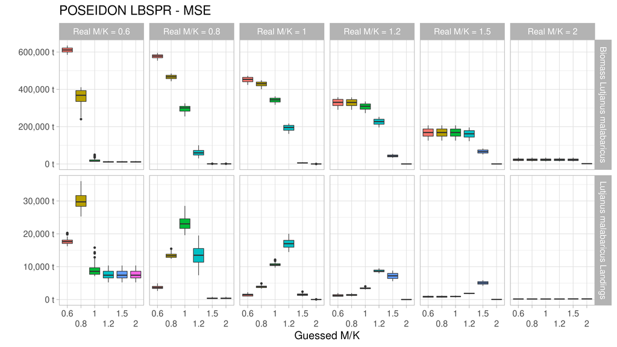

Top row shows the average biomass left at the end of the simulation. The baseline changes with the real $\frac M K$, but it is always the case that the lower we assume $\frac M K$ to be when computing SPR, the higher the final biomass will be. Guessing it too high often results in complete collapse. The bottom row shows the average landings in the last 10 years of the simulation (runs for 60 years total). The summary of the result is just that if you want to maximize landings, you want to get the $\frac M K$ about right. In fact in POSEIDON the $\frac M K$ that computes SPR needs to be slightly higher than the real one to maximize long term landings. This is because geographically the fishers tend to focus close to port, fishing in locally depleted areas. Because of this the SPR that you compute is already more pessimistic than what is really going on under the sea. You need to use a higher $\frac M K$ to “balance it out”.

The tradeoff is basically the same in the DLMtoolkit[^1] except for the usual problem that MERA questionaire is very optimistic and that effort is exogenous so you don’t actually risk any collapse. In the DLM toolkit then, the tradeoff between long term landings and biomass left is almost linear: the higher you guess $\frac M K$ the more you increase one at the expense of the other

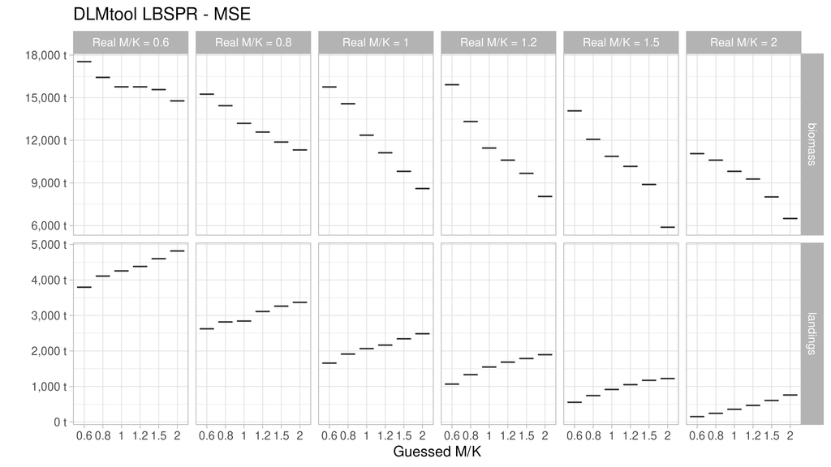

[^1]: There is actually a bug in the way the LBSPR policy is coded in DLMtool/MERA, which is maybe why they took it out. It was coded correctly about a year ago but they must have accidentally changed it. Here I am forcing the older version